# Study II - Beta-diversity analyses of metaphlan profiles

Florentin Constancias

November 20, 2024

```r
load(here::here("../../data/processed_data/metaphlan/01_data.Rdata"))
load(here::here("../../data/processed_data/metaphlan/02_data.Rdata"))
```

```r
pd <- position_dodge(0.3)
```

Let’s source the function:

```r
source("https://raw.githubusercontent.com/fconstancias/KU_Caroline/refs/heads/main/code/functions/phyloseq_functions.R")

# details:

#' @title This function calculates beta diversity, generates ordination plots (e.g., PCoA),  performs PERMANOVA, and optionally creates boxplots of distances between metadata groups.
#' @author Florentin Constancias
#' @param ps_up A phyloseq object containing microbiome data.
#' @param beta A list of distance matrices for beta diversity (e.g., Bray-Curtis, Aitchison).
#' @param m Character string specifying the ordination method (default: "PCoA").
#' @param color_group Character string for the variable used to color points in ordination plots (default: "Time").
#' @param shape_group Character string for the variable used to shape points in ordination plots (default: "Sample").
#' @param alpha Optional variable for transparency adjustment in ordination plots (default: NULL).
#' @param col_pal Color palette for point colors (default: `time_pal`).
#' @param fill_pal Fill color palette for point fills (default: `time_pal`).
#' @param path_group Character string for the variable grouping paths in ordination plots (default: "interaction(Sample,Subject)").
#' @param facet_formula Formula for faceting ordination plots (default: "Sample ~ .").
#' @param axis1 Integer specifying the ordination axis to plot on the x-axis (default: 1).
#' @param axis2 Integer specifying the ordination axis to plot on the y-axis (default: 2).
#' @param seed Integer for random seed, ensuring reproducible results in ordination (default: 123).
#' @param permanova_terms Character vector of variables for PERMANOVA tests (default: c("Time", "cluster_Dtp2")).
#' @param metadata_dist_boxplot Optional variable for generating distance boxplots (default: NULL).
#' @param strata Variable for stratified PERMANOVA testing (default: "none").
#' @param perm Number of permutations for PERMANOVA (default: 999).
#'
#' @return A list of results, including:
#'   - `pcoas`: Ordination plots with faceting and custom color/shape groups.
#'   - `expl_var`: Explained variance for each axis in ordination plots.
#'   - `PCOA`: Detailed ordination plot for the rAitchison distance with paths.
#'   - `PCOA_leg`: Legend for the ordination plot.
#'   - `perm`: PERMANOVA results.
#'   - `pw_perm`: Pairwise PERMANOVA results for each variable in `permanova_terms`.
#'   - `tw_perm`: Two-way PERMANOVA results for each variable in `permanova_terms`.
#'   - Optional: `dist_boxplot` if `metadata_dist_boxplot` is provided, showing boxplots of distances.
```

# Compute the distance for all samples:

# Run fonction for full dataset:

Explore PCoA : distances show similar patterns

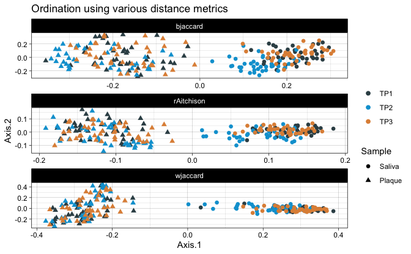

```r
out$pcoas
```

Explained variance of the plots above.

```r
out$expl_var %>%
  mutate_if(is.numeric, ~round(., 3)) %>%
  DT::datatable()
```

|  | .id...1 | V1...2 | .id...3 | V1...4 |
| --- | --- | --- | --- | --- |
| 1 | bjaccard | Axis.1 [21%] | bjaccard | Axis.2 [9.9%] |
| 2 | wjaccard | Axis.1 [19.9%] | wjaccard | Axis.2 [5.9%] |
| 3 | rAitchison | Axis.1 [20%] | rAitchison | Axis.2 [3.9%] |

Focus on Robust Aitchinson distance, clear discrimination between site, display trajectories.

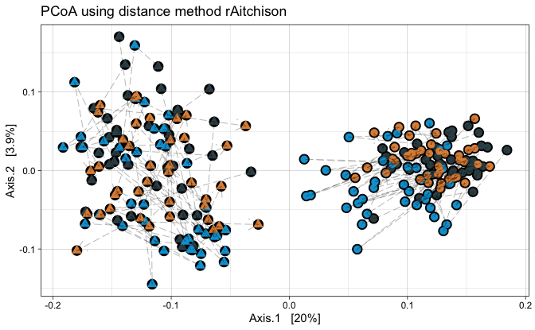

```r
out$PCOA + facet_null()
```

Corresponding legend:

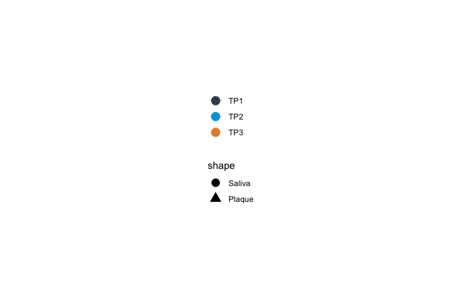

```r
out$PCOA_leg
```

Statistical evaluation of the beta diversity: association with Sample_Type, Time and Cluster of inflamation at TP2 -PERMANOVA:

Sample Type explain most of the variation (R2) > Time > Cluster

More info: https://gist.github.com/claczny/3415270a6c6919969bff79d2c246a527

```r
out$perm %>%
  mutate_if(is.double, ~round(., 3)) %>%
  dplyr::filter(Distance == "rAitchison", terms_margin == "terms") %>%
  DT::datatable()
```

|  | Distance | terms | Df | SumOfSqs | R2 | F | Pr(>F) | Group | terms_margin |
| --- | --- | --- | --- | --- | --- | --- | --- | --- | --- |
| 1 | rAitchison | Sample | 1 | 3.11 | 0.183 | 54.326 | 0.001 | Sample * Time * cluster_Dtp2 | terms |
| 2 | rAitchison | Time | 2 | 0.318 | 0.019 | 2.778 | 0.001 | Sample * Time * cluster_Dtp2 | terms |
| 3 | rAitchison | cluster_Dtp2 | 2 | 0.175 | 0.01 | 1.527 | 0.027 | Sample * Time * cluster_Dtp2 | terms |
| 4 | rAitchison | Sample:Time | 2 | 0.263 | 0.015 | 2.298 | 0.001 | Sample * Time * cluster_Dtp2 | terms |
| 5 | rAitchison | Sample:cluster_Dtp2 | 2 | 0.142 | 0.008 | 1.236 | 0.129 | Sample * Time * cluster_Dtp2 | terms |
| 6 | rAitchison | Time:cluster_Dtp2 | 4 | 0.214 | 0.013 | 0.933 | 0.605 | Sample * Time * cluster_Dtp2 | terms |
| 7 | rAitchison | Sample:Time:cluster_Dtp2 | 4 | 0.165 | 0.01 | 0.722 | 0.998 | Sample * Time * cluster_Dtp2 | terms |
| 8 | rAitchison | Residual | 221 | 12.652 | 0.743 |  |  | Sample * Time * cluster_Dtp2 | terms |
| 9 | rAitchison | Total | 238 | 17.039 | 1 |  |  | Sample * Time * cluster_Dtp2 | terms |
| 10 | rAitchison | Sample | 1 | 3.11 | 0.183 | 53.935 | 0.001 | Sample + Time + cluster_Dtp2 | terms |

[output cut: 4 more lines]

Statistical evaluation of the beta diversity - Pairwise PERMANOVA tests between Time, Sample Type, Inflamation response clusters:

```r
out$pw_perm %>%
  dplyr::filter(Distance == "rAitchison") %>%
  mutate_if(is.numeric, ~round(., 3)) %>%
  DT::datatable()
```

|  | Distance | X1 | X2 | R2 | pval | pvalBon | pvalFDR | Group |
| --- | --- | --- | --- | --- | --- | --- | --- | --- |
| 1 | rAitchison | 1 | 2 | 0.009 | 0.148 | 0.444 | 0.222 | cluster_Dtp2 |
| 2 | rAitchison | 1 | 3 | 0.007 | 0.214 | 0.642 | 0.214 | cluster_Dtp2 |
| 3 | rAitchison | 2 | 3 | 0.007 | 0.134 | 0.402 | 0.402 | cluster_Dtp2 |
| 4 | rAitchison | TP1 | TP2 | 0.018 | 0.001 | 0.003 | 0.003 | Time |
| 5 | rAitchison | TP1 | TP3 | 0.008 | 0.155 | 0.465 | 0.155 | Time |
| 6 | rAitchison | TP2 | TP3 | 0.017 | 0.002 | 0.006 | 0.003 | Time |
| 7 | rAitchison | Saliva | Plaque | 0.183 | 0.001 | 0.001 | 0.001 | Sample |

We could also play the intra-subject distance accross time | maybe with within group variation for TP1: within TP1 / Sample:

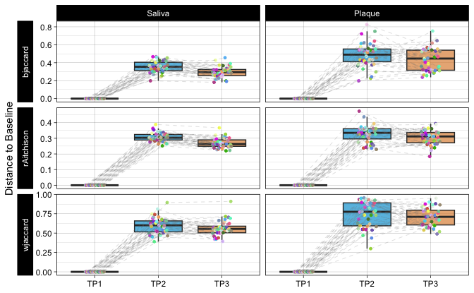

```r
out$dist_box
```

```r
# out$tw_perm %>%
#   DT::datatable()
```

We can also explore the groups of the different variables:

Sample

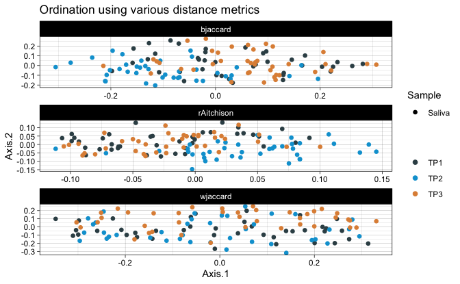

```r
out$Sample$Saliva
```

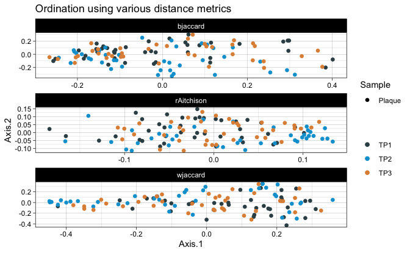

```r
out$Sample$Plaque
```

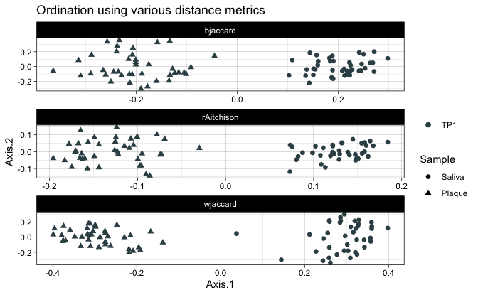

```r
out$Time$TP1
```

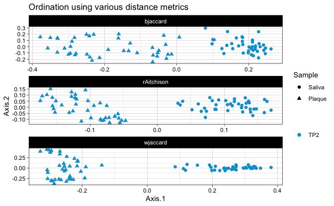

```r
out$Time$TP2
```

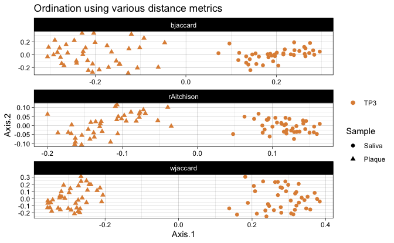

```r
out$Time$TP3
```

# Now we can explore more Saliva and Plaque samples:

## Saliva:

```r
ps_up %>%
  subset_samples(Sample == "Saliva") %>%
  subset_taxa(Class != "UNCLASSIFIED") %>%
  transform_sample_counts(function(x) x/sum(x) * 1) %>%
  microViz::ps_mutate(cluster_Dtp2 = as.factor(cluster_Dtp2)) %>%
  compute_plot_beta(ps_up = .,
                    beta = beta,
                    color_group = "Time",
                    shape_group = "Sample",
                    alpha = NULL,
                    col_pal = time_pal,
                    fill_pal = time_pal,
                    path_group = "interaction(Subject)",
                    facet_formula = "Sample ~ .",
                    axis1 = 1,
                    axis2 = 2,
                    seed = 123,
                    permanova_terms = c("Time","cluster_Dtp2"),
                    # metadata_dist_boxplot = NULL ,
                    strata = "none") -> saliva
```

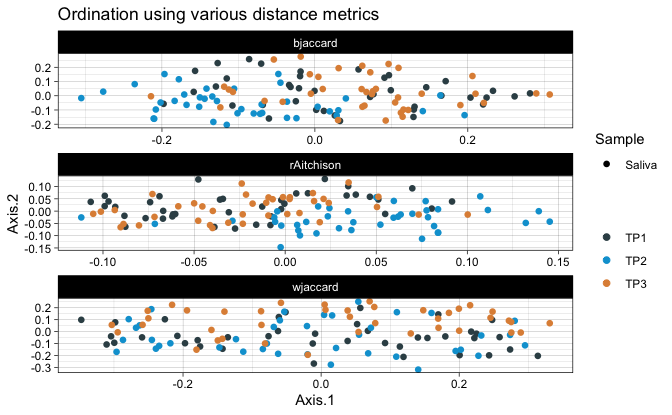

```r
saliva$pcoas
```

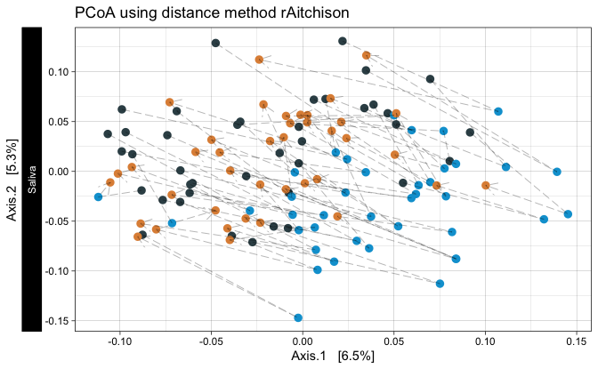

```r
saliva$PCOA
```

```r
saliva$perm %>%
  mutate_if(is.double, ~round(., 3)) %>%
  dplyr::filter(Distance == "rAitchison", terms_margin == "terms") %>%
  DT::datatable()
```

|  | Distance | terms | Df | SumOfSqs | R2 | F | Pr(>F) | Group | terms_margin |
| --- | --- | --- | --- | --- | --- | --- | --- | --- | --- |
| 1 | rAitchison | Time | 2 | 0.335 | 0.051 | 3.133 | 0.001 | Time * cluster_Dtp2 | terms |
| 2 | rAitchison | cluster_Dtp2 | 2 | 0.15 | 0.023 | 1.402 | 0.002 | Time * cluster_Dtp2 | terms |
| 3 | rAitchison | Time:cluster_Dtp2 | 4 | 0.161 | 0.024 | 0.754 | 1 | Time * cluster_Dtp2 | terms |
| 4 | rAitchison | Residual | 111 | 5.942 | 0.902 |  |  | Time * cluster_Dtp2 | terms |
| 5 | rAitchison | Total | 119 | 6.589 | 1 |  |  | Time * cluster_Dtp2 | terms |
| 6 | rAitchison | Time | 2 | 0.335 | 0.051 | 3.16 | 0.001 | Time + cluster_Dtp2 | terms |
| 7 | rAitchison | cluster_Dtp2 | 2 | 0.15 | 0.023 | 1.414 | 0.003 | Time + cluster_Dtp2 | terms |
| 8 | rAitchison | Residual | 115 | 6.103 | 0.926 |  |  | Time + cluster_Dtp2 | terms |
| 9 | rAitchison | Total | 119 | 6.589 | 1 |  |  | Time + cluster_Dtp2 | terms |

Pairwise comparisons between groups: Time, …

Interesting to see that when considering only presence and absence of taxa (i.e., binary bJaccard), no significant differences between TP1 and TP3, but still when considering proportion of taxa.

```r
saliva$pw_perm %>%
  # dplyr::filter(Distance == "rAitchison") %>%
  mutate_if(is.numeric, ~round(., 3)) %>%
  DT::datatable()
```

|  | Distance | X1 | X2 | R2 | pval | pvalBon | pvalFDR | Group |
| --- | --- | --- | --- | --- | --- | --- | --- | --- |
| 1 | bjaccard | 1 | 2 | 0.034 | 0.003 | 0.009 | 0.009 | cluster_Dtp2 |
| 2 | bjaccard | 1 | 3 | 0.025 | 0.016 | 0.048 | 0.016 | cluster_Dtp2 |
| 3 | bjaccard | 2 | 3 | 0.02 | 0.005 | 0.015 | 0.007 | cluster_Dtp2 |
| 4 | wjaccard | 1 | 2 | 0.023 | 0.032 | 0.096 | 0.096 | cluster_Dtp2 |
| 5 | wjaccard | 1 | 3 | 0.019 | 0.041 | 0.123 | 0.062 | cluster_Dtp2 |
| 6 | wjaccard | 2 | 3 | 0.013 | 0.238 | 0.714 | 0.238 | cluster_Dtp2 |
| 7 | rAitchison | 1 | 2 | 0.023 | 0.003 | 0.009 | 0.009 | cluster_Dtp2 |
| 8 | rAitchison | 1 | 3 | 0.018 | 0.022 | 0.066 | 0.033 | cluster_Dtp2 |
| 9 | rAitchison | 2 | 3 | 0.013 | 0.095 | 0.285 | 0.095 | cluster_Dtp2 |
| 10 | bjaccard | TP1 | TP2 | 0.073 | 0.001 | 0.003 | 0.002 | Time |

[output cut: 8 more lines]

```r
# saliva$tw_perm %>%
#   DT::datatable()
```

We could test if the distance between saliva and plaque per individual changes over time:

```r
saliva$dist_box
```

[output not shown]

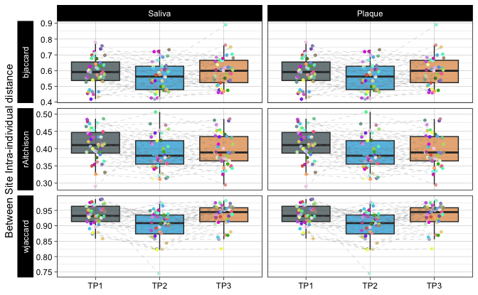

```r
out$dist_df %>%
  dplyr::filter(Sample_1 != Sample_2,
                Time_1 == Time_2,
                Subject_1 == Subject_2) %>%
  arrange(Distance, Subject_2, Time_2) %>%
  ggplot(data = ., aes_string(x="Time_2", y="value")) +
  geom_boxplot(outlier.colour = NA, alpha=0.7, aes_string(fill = "Time_2")) +
  geom_jitter(size=1, position = pd, aes_string(color = "Subject_1")) +
  geom_line(aes_string(group="Subject_1"), position = pd, linetype = "dashed", color = "grey50", linewidth = 0.08) +
  facet_grid(as.formula(paste0("Distance ~ Sample_1")), scales = "free_y", space = "fixed", switch = "y") +
  scale_color_manual(name = "", values = sub_pal,
                     na.value = "black") +
  scale_fill_manual(name = "", values = time_pal,
                    na.value = "black") +
  theme_light() + ylab("Between Site Intra-individual distance ") + xlab(NULL) + theme(
    axis.text.x = element_blank()) +  theme_linedraw() + theme(strip.placement = "outside") -> d_box

d_box %>%
  ggpubr::get_legend(.) %>%
  ggpubr::as_ggplot(.) -> d_box_leg

d_box + theme(legend.position = "none") -> d_box

d_box
```

## Plaque:

```r
ps_up %>%
  subset_samples(Sample == "Plaque") %>%
  subset_taxa(Class != "UNCLASSIFIED") %>%
  transform_sample_counts(function(x) x/sum(x) * 1) %>%
  microViz::ps_mutate(cluster_Dtp2 = as.factor(cluster_Dtp2)) %>%
  compute_plot_beta(ps_up = .,
                    beta = beta,
                    color_group = "Time",
                    shape_group = "Sample",
                    alpha = NULL,
                    col_pal = time_pal,
                    fill_pal = time_pal,
                    path_group = "interaction(Subject)",
                    facet_formula = "Sample ~ .",
                    axis1 = 1,
                    axis2 = 2,
                    seed = 123,
                    permanova_terms = c("Time","cluster_Dtp2"),
                    # metadata_dist_boxplot = NULL ,
                    strata = "none") -> plaque
```

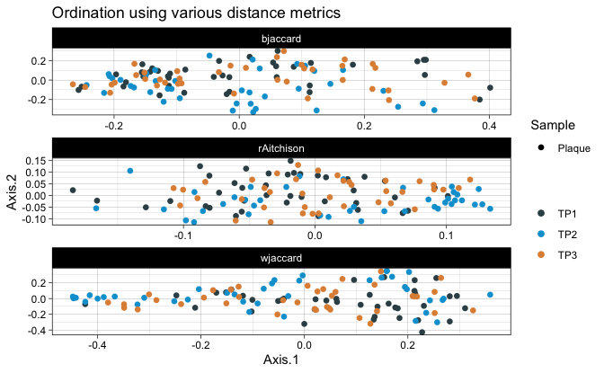

```r
plaque$pcoas
```

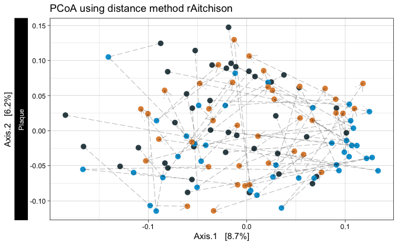

```r
plaque$PCOA
```

```r
plaque$perm %>%
  mutate_if(is.double, ~round(., 3)) %>%
  dplyr::filter(Distance == "rAitchison", terms_margin == "terms") %>%
  DT::datatable()
```

|  | Distance | terms | Df | SumOfSqs | R2 | F | Pr(>F) | Group | terms_margin |
| --- | --- | --- | --- | --- | --- | --- | --- | --- | --- |
| 1 | rAitchison | Time | 2 | 0.246 | 0.034 | 2.016 | 0.001 | Time * cluster_Dtp2 | terms |
| 2 | rAitchison | cluster_Dtp2 | 2 | 0.166 | 0.023 | 1.362 | 0.01 | Time * cluster_Dtp2 | terms |
| 3 | rAitchison | Time:cluster_Dtp2 | 4 | 0.218 | 0.03 | 0.892 | 0.888 | Time * cluster_Dtp2 | terms |
| 4 | rAitchison | Residual | 110 | 6.71 | 0.914 |  |  | Time * cluster_Dtp2 | terms |
| 5 | rAitchison | Total | 118 | 7.34 | 1 |  |  | Time * cluster_Dtp2 | terms |
| 6 | rAitchison | Time | 2 | 0.246 | 0.034 | 2.024 | 0.001 | Time + cluster_Dtp2 | terms |
| 7 | rAitchison | cluster_Dtp2 | 2 | 0.166 | 0.023 | 1.367 | 0.01 | Time + cluster_Dtp2 | terms |
| 8 | rAitchison | Residual | 114 | 6.928 | 0.944 |  |  | Time + cluster_Dtp2 | terms |
| 9 | rAitchison | Total | 118 | 7.34 | 1 |  |  | Time + cluster_Dtp2 | terms |

Pairwise comparisons between groups: Time, …

Interesting to compare between saliva and plaque… Maybe a plot displaying R2 and adjpavalue?

```r
plaque$pw_perm %>%
  # dplyr::filter(Distance == "rAitchison") %>%
  mutate_if(is.numeric, ~round(., 3)) %>%
  DT::datatable()
```

|  | Distance | X1 | X2 | R2 | pval | pvalBon | pvalFDR | Group |
| --- | --- | --- | --- | --- | --- | --- | --- | --- |
| 1 | bjaccard | 1 | 2 | 0.027 | 0.019 | 0.057 | 0.028 | cluster_Dtp2 |
| 2 | bjaccard | 1 | 3 | 0.022 | 0.03 | 0.09 | 0.03 | cluster_Dtp2 |
| 3 | bjaccard | 2 | 3 | 0.025 | 0.001 | 0.003 | 0.003 | cluster_Dtp2 |
| 4 | wjaccard | 1 | 2 | 0.023 | 0.041 | 0.123 | 0.041 | cluster_Dtp2 |
| 5 | wjaccard | 1 | 3 | 0.021 | 0.033 | 0.099 | 0.05 | cluster_Dtp2 |
| 6 | wjaccard | 2 | 3 | 0.018 | 0.019 | 0.057 | 0.057 | cluster_Dtp2 |
| 7 | rAitchison | 1 | 2 | 0.018 | 0.092 | 0.276 | 0.138 | cluster_Dtp2 |
| 8 | rAitchison | 1 | 3 | 0.016 | 0.133 | 0.399 | 0.133 | cluster_Dtp2 |
| 9 | rAitchison | 2 | 3 | 0.017 | 0.008 | 0.024 | 0.024 | cluster_Dtp2 |
| 10 | bjaccard | TP1 | TP2 | 0.041 | 0.001 | 0.003 | 0.002 | Time |

[output cut: 8 more lines]

```r
plaque$tw_perm %>%
  DT::datatable()
```

|  | Distance | Level1 | Level2 | N1 | N2 | p.value | tw2.stat | nrep | pvalFDR | Group |
| --- | --- | --- | --- | --- | --- | --- | --- | --- | --- | --- |
| 1 | bjaccard | ['1'] | ['2'] | [26] | [42] | [0.032] | [1.73461418947618] | [999] | 0.04 | cluster_Dtp2 |
| 2 | bjaccard | ['1'] | ['3'] | [26] | [51] | [0.04] | [1.634795735512252] | [999] | 0.04 | cluster_Dtp2 |
| 3 | bjaccard | ['2'] | ['3'] | [42] | [51] | [0.003] | [2.365034924791286] | [999] | 0.009000000000000001 | cluster_Dtp2 |
| 4 | wjaccard | ['1'] | ['2'] | [26] | [42] | [0.047] | [1.495570207723217] | [999] | 0.047 | cluster_Dtp2 |
| 5 | wjaccard | ['1'] | ['3'] | [26] | [51] | [0.037] | [1.548623281171168] | [999] | 0.047 | cluster_Dtp2 |
| 6 | wjaccard | ['2'] | ['3'] | [42] | [51] | [0.016] | [1.671255386679231] | [999] | 0.047 | cluster_Dtp2 |
| 7 | rAitchison | ['1'] | ['2'] | [26] | [42] | [0.097] | [1.235564436552785] | [999] | 0.128 | cluster_Dtp2 |
| 8 | rAitchison | ['1'] | ['3'] | [26] | [51] | [0.128] | [1.19799955626987] | [999] | 0.128 | cluster_Dtp2 |
| 9 | rAitchison | ['2'] | ['3'] | [42] | [51] | [0.003] | [1.555500854485347] | [999] | 0.009000000000000001 | cluster_Dtp2 |
| 10 | bjaccard | ['TP1'] | ['TP2'] | [40] | [40] | [0.001] | [3.35603097867184] | [999] | 0.0015 | Time |

[output cut: 8 more lines]

Display PERMANOVA results as a plot - in progress:

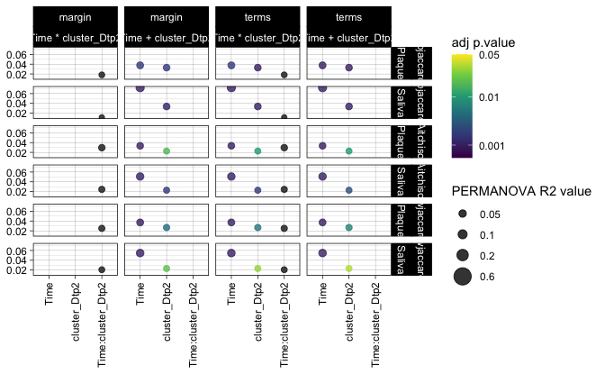

```r
permanova_terms = c("Time","cluster_Dtp2")


saliva$perm %>%
  mutate(Data = "Saliva") %>%
  rbind(.,
        plaque$perm %>%
          mutate(Data = "Plaque")
  ) %>%
  filter(!terms %in% c("Residual","Total")) %>%
  mutate(terms = fct_relevel(terms, c(permanova_terms, "Time:cluster_Dtp2"))) %>%
  # arrange(Distance, Group2) %>%
  # filter(p.adj <= 0.05) %>%
  # mutate(p.adj = replace(p.adj, p.adj > 0.05, NA)) %>%
  ggplot(mapping = aes(x = terms,
                       y = R2, #`Pr(>F)` ,
                       size = R2,
                       # fill = `Pr(>F)`,
                       color = `Pr(>F)`)) + #,
  # size = R2)) +
  facet_grid(Distance + Data ~ terms_margin+ Group,  scales = "fixed", space = "fixed", drop = FALSE) +
  geom_point(alpha=0.8) +
  # geom_tile() +
  # geom_bar(stat="identity") +
  theme_linedraw() +
  xlab(NULL) + ylab(NULL) +
  scale_size(range = c(1, 8),
             breaks = c(0.05, 0.1,0.2,0.6),
             labels = c(0.05, 0.1,0.2,0.6),
             limits = c(0,1),
             # trans = "sqrt",
             name="PERMANOVA R2 value") +
  scale_color_viridis_c(name = "adj p.value",
                        na.value = "grey10",
                        trans = scales::pseudo_log_trans(sigma = 0.001),
                        limits = c(0,0.05),
                        breaks = c(1,0.05, 0.01, 0.001),
                        labels = c(1,0.05, 0.01, 0.001)) +
  theme(axis.text.x = element_text(angle = 90, hjust = 1, vjust = 0.5)) #+
```

```r
# coord_equal()
```

Site across time?

```r
tmp = ps_up
group = "Time"
Time_out=NULL
# Time_out <- vector("list", length(tmp %>%
#                                get_variable(group) %>%
#                                levels()))
# names(Time_out) <- tmp %>%
#   get_variable(group) %>% levels()

for(tp in tmp %>%
    get_variable(group) %>%
    unique()){

  prune_samples(get_variable(tmp, group) == tp,
                tmp) %>%
    subset_taxa(Class != "UNCLASSIFIED") %>%
    transform_sample_counts(function(x) x/sum(x) * 1) %>%
    microViz::ps_mutate(cluster_Dtp2 = as.factor(cluster_Dtp2)) %>%
    compute_plot_beta(ps_up = .,
                      beta = beta,
                      color_group = "Sample",
                      shape_group = "Sample",
                      alpha = NULL,
                      col_pal = sample_pal,
                      fill_pal = sample_pal,
                      path_group = "interaction(Subject)",
                      facet_formula = "Sample ~ .",
                      axis1 = 1,
                      axis2 = 2,
                      seed = 123,
                      permanova_terms = c("Sample"),
                      metadata_dist_boxplot = NULL ,
                      strata = "none") -> Time_out[[tp]]
}
```

```r
Time_out %>%
  plyr::ldply(., function(x) x$perm) %>%
  rename(Time = '.id') %>%
  DT::datatable()
```

|  | Time | Distance | terms | Df | SumOfSqs | R2 | F | Pr(>F) | Group | terms_margin |
| --- | --- | --- | --- | --- | --- | --- | --- | --- | --- | --- |
| 1 | TP1 | bjaccard | Sample | 1 | 3.248473994802223 | 0.2081808283697552 | 20.50733954749913 | 0.001 | Sample | margin |
| 2 | TP1 | bjaccard | Residual | 78 | 12.35562375156915 | 0.7918191716302444 |  |  | Sample | margin |
| 3 | TP1 | bjaccard | Total | 79 | 15.60409774637138 | 1 |  |  | Sample | margin |
| 4 | TP1 | wjaccard | Sample | 1 | 6.85446847203233 | 0.2322502394670901 | 23.5956031635343 | 0.001 | Sample | margin |
| 5 | TP1 | wjaccard | Residual | 78 | 22.65882067574316 | 0.7677497605329098 |  |  | Sample | margin |
| 6 | TP1 | wjaccard | Total | 79 | 29.5132891477755 | 1 |  |  | Sample | margin |
| 7 | TP1 | rAitchison | Sample | 1 | 1.318247494652351 | 0.2293378652217914 | 23.21166783735634 | 0.001 | Sample | margin |
| 8 | TP1 | rAitchison | Residual | 78 | 4.429811132201448 | 0.770662134778209 |  |  | Sample | margin |
| 9 | TP1 | rAitchison | Total | 79 | 5.748058626853797 | 1 |  |  | Sample | margin |
| 10 | TP1 | bjaccard | Sample | 1 | 3.248473994802233 | 0.2081808283697558 | 20.50733954749919 | 0.001 | Sample | terms |

[output cut: 98 more lines]

At baseline, TP2, TP3: impact of clusterdtp2 in the diff site?

```r
tmp = ps_up
group = "Time"
Time_out_clust=NULL
# Time_out <- vector("list", length(tmp %>%
#                                get_variable(group) %>%
#                                levels()))
# names(Time_out) <- tmp %>%
#   get_variable(group) %>% levels()

for(tp in tmp %>%
    get_variable(group) %>%
    unique()){

  prune_samples(get_variable(tmp, group) == tp,
                tmp) %>%
    subset_taxa(Class != "UNCLASSIFIED") %>%
    transform_sample_counts(function(x) x/sum(x) * 1) %>%
    microViz::ps_mutate(cluster_Dtp2 = as.factor(cluster_Dtp2)) %>%
    compute_plot_beta(ps_up = .,
                      beta = beta,
                      color_group = "Sample",
                      shape_group = "Sample",
                      alpha = NULL,
                      col_pal = sample_pal,
                      fill_pal = sample_pal,
                      path_group = "interaction(Subject)",
                      facet_formula = "Sample ~ .",
                      axis1 = 1,
                      axis2 = 2,
                      seed = 123,
                      permanova_terms = c("Sample", "cluster_Dtp2"),
                      metadata_dist_boxplot = NULL ,
                      strata = "none") -> Time_out_clust[[tp]]
}
```

```r
Time_out_clust %>%
  plyr::ldply(., function(x) x$perm) %>%
  rename(Time = '.id') %>%
  DT::datatable()
```

|  | Time | Distance | terms | Df | SumOfSqs | R2 | F | Pr(>F) | Group | terms_margin |
| --- | --- | --- | --- | --- | --- | --- | --- | --- | --- | --- |
| 1 | TP1 | bjaccard | Sample:cluster_Dtp2 | 2 | 0.1899081173955963 | 0.0121704003962522 | 0.5979780935396143 | 0.989 | Sample * cluster_Dtp2 | margin |
| 2 | TP1 | bjaccard | Residual | 74 | 11.75059825694362 | 0.7530456709473089 |  |  | Sample * cluster_Dtp2 | margin |
| 3 | TP1 | bjaccard | Total | 79 | 15.60409774637138 | 1 |  |  | Sample * cluster_Dtp2 | margin |
| 4 | TP1 | wjaccard | Sample:cluster_Dtp2 | 2 | 0.4758552371934641 | 0.01612342273376638 | 0.8135023925336999 | 0.787 | Sample * cluster_Dtp2 | margin |
| 5 | TP1 | wjaccard | Residual | 74 | 21.64301412970805 | 0.7333311452118967 |  |  | Sample * cluster_Dtp2 | margin |
| 6 | TP1 | wjaccard | Total | 79 | 29.5132891477755 | 1 |  |  | Sample * cluster_Dtp2 | margin |
| 7 | TP1 | rAitchison | Sample:cluster_Dtp2 | 2 | 0.1023239468828825 | 0.01780147933857967 | 0.8986715274913711 | 0.581 | Sample * cluster_Dtp2 | margin |
| 8 | TP1 | rAitchison | Residual | 74 | 4.212869684694672 | 0.7329204446546483 |  |  | Sample * cluster_Dtp2 | margin |
| 9 | TP1 | rAitchison | Total | 79 | 5.748058626853797 | 1 |  |  | Sample * cluster_Dtp2 | margin |
| 10 | TP1 | bjaccard | Sample | 1 | 3.248473994802233 | 0.2081808283697558 | 20.45743292034655 | 0.001 | Sample * cluster_Dtp2 | terms |

[output cut: 134 more lines]

Saliva

```r
tmp = ps_up %>%
  subset_samples(Sample == "Saliva")
group = "Time"
Time_out_saliva_clust=NULL
# Time_out <- vector("list", length(tmp %>%
#                                get_variable(group) %>%
#                                levels()))
# names(Time_out) <- tmp %>%
#   get_variable(group) %>% levels()

for(tp in tmp %>%
    get_variable(group) %>%
    unique()){

  prune_samples(get_variable(tmp, group) == tp,
                tmp) %>%
    subset_taxa(Class != "UNCLASSIFIED") %>%
    transform_sample_counts(function(x) x/sum(x) * 1) %>%
    microViz::ps_mutate(cluster_Dtp2 = as.factor(cluster_Dtp2)) %>%
    compute_plot_beta(ps_up = .,
                      beta = beta,
                      color_group = "Sample",
                      shape_group = "Sample",
                      alpha = NULL,
                      col_pal = sample_pal,
                      fill_pal = sample_pal,
                      path_group = "interaction(Subject)",
                      facet_formula = "Sample ~ .",
                      axis1 = 1,
                      axis2 = 2,
                      seed = 123,
                      permanova_terms = c("cluster_Dtp2"),
                      metadata_dist_boxplot = NULL ,
                      strata = "none") -> Time_out_saliva_clust[[tp]]
}
```

```r
Time_out_saliva_clust %>%
  plyr::ldply(., function(x) x$perm) %>%
  rename(Time = '.id') %>%
  DT::datatable()
```

|  | Time | Distance | terms | Df | SumOfSqs | R2 | F | Pr(>F) | Group | terms_margin |
| --- | --- | --- | --- | --- | --- | --- | --- | --- | --- | --- |
| 1 | TP1 | bjaccard | cluster_Dtp2 | 2 | 0.2338107665787152 | 0.04655238210232678 | 0.9032683628619379 | 0.669 | cluster_Dtp2 | margin |
| 2 | TP1 | bjaccard | Residual | 37 | 4.788719897153503 | 0.9534476178976728 |  |  | cluster_Dtp2 | margin |
| 3 | TP1 | bjaccard | Total | 39 | 5.02253066373222 | 1 |  |  | cluster_Dtp2 | margin |
| 4 | TP1 | wjaccard | cluster_Dtp2 | 2 | 0.3945439815163461 | 0.04303742508078721 | 0.8319994792500413 | 0.787 | cluster_Dtp2 | margin |
| 5 | TP1 | wjaccard | Residual | 37 | 8.772918541525685 | 0.9569625749192124 |  |  | cluster_Dtp2 | margin |
| 6 | TP1 | wjaccard | Total | 39 | 9.167462523042035 | 1 |  |  | cluster_Dtp2 | margin |
| 7 | TP1 | rAitchison | cluster_Dtp2 | 2 | 0.09303147350633423 | 0.04623058586206044 | 0.8967218132289839 | 0.877 | cluster_Dtp2 | margin |
| 8 | TP1 | rAitchison | Residual | 37 | 1.919304554073219 | 0.9537694141379389 |  |  | cluster_Dtp2 | margin |
| 9 | TP1 | rAitchison | Total | 39 | 2.012336027579555 | 1 |  |  | cluster_Dtp2 | margin |
| 10 | TP1 | bjaccard | cluster_Dtp2 | 2 | 0.2338107665787189 | 0.04655238210232751 | 0.903268362861952 | 0.68 | cluster_Dtp2 | terms |

[output cut: 98 more lines]

Plaque

```r
tmp = ps_up %>%
  subset_samples(Sample == "Plaque")
group = "Time"
Time_out_plaque_clust=NULL
# Time_out <- vector("list", length(tmp %>%
#                                get_variable(group) %>%
#                                levels()))
# names(Time_out) <- tmp %>%
#   get_variable(group) %>% levels()

for(tp in tmp %>%
    get_variable(group) %>%
    unique()){

  prune_samples(get_variable(tmp, group) == tp,
                tmp) %>%
    subset_taxa(Class != "UNCLASSIFIED") %>%
    transform_sample_counts(function(x) x/sum(x) * 1) %>%
    microViz::ps_mutate(cluster_Dtp2 = as.factor(cluster_Dtp2)) %>%
    compute_plot_beta(ps_up = .,
                      beta = beta,
                      color_group = "Sample",
                      shape_group = "Sample",
                      alpha = NULL,
                      col_pal = sample_pal,
                      fill_pal = sample_pal,
                      path_group = "interaction(Subject)",
                      facet_formula = "Sample ~ .",
                      axis1 = 1,
                      axis2 = 2,
                      seed = 123,
                      permanova_terms = c("cluster_Dtp2"),
                      metadata_dist_boxplot = NULL ,
                      strata = "none") -> Time_out_plaque_clust[[tp]]
}
```

```r
Time_out_plaque_clust %>%
  plyr::ldply(., function(x) x$perm) %>%
  rename(Time = '.id') %>%
  DT::datatable()
```

|  | Time | Distance | terms | Df | SumOfSqs | R2 | F | Pr(>F) | Group | terms_margin |
| --- | --- | --- | --- | --- | --- | --- | --- | --- | --- | --- |
| 1 | TP1 | bjaccard | cluster_Dtp2 | 2 | 0.3712147280467937 | 0.05062184859790082 | 0.9864395948843767 | 0.457 | cluster_Dtp2 | margin |
| 2 | TP1 | bjaccard | Residual | 37 | 6.961878359790128 | 0.949378151402099 |  |  | cluster_Dtp2 | margin |
| 3 | TP1 | bjaccard | Total | 39 | 7.333093087836922 | 1 |  |  | cluster_Dtp2 | margin |
| 4 | TP1 | wjaccard | cluster_Dtp2 | 2 | 0.621262564518771 | 0.04604892683798382 | 0.8930281336955063 | 0.725 | cluster_Dtp2 | margin |
| 5 | TP1 | wjaccard | Residual | 37 | 12.87009558818236 | 0.9539510731620162 |  |  | cluster_Dtp2 | margin |
| 6 | TP1 | wjaccard | Total | 39 | 13.49135815270113 | 1 |  |  | cluster_Dtp2 | margin |
| 7 | TP1 | rAitchison | cluster_Dtp2 | 2 | 0.1239099740004366 | 0.05125594624057848 | 0.9994634503302527 | 0.434 | cluster_Dtp2 | margin |
| 8 | TP1 | rAitchison | Residual | 37 | 2.293565130621456 | 0.9487440537594213 |  |  | cluster_Dtp2 | margin |
| 9 | TP1 | rAitchison | Total | 39 | 2.417475104621893 | 1 |  |  | cluster_Dtp2 | margin |
| 10 | TP1 | bjaccard | cluster_Dtp2 | 2 | 0.3712147280467973 | 0.05062184859790131 | 0.9864395948843864 | 0.451 | cluster_Dtp2 | terms |

[output cut: 98 more lines]

```r
save(Time_out_plaque_clust, Time_out_saliva_clust, Time_out_clust, Time_out, plaque, saliva, d_box, d_box_leg,
     ps_up,
     sample_pal,
     time_pal, sub_pal, sex_pal, sample_pal, period_pal,
     file = here::here("../../data/processed_data/metaphlan/03_data.Rdata"))
```